# Project Proposal – Income vs Prices (Singapore, 2000–2025)

Authors

Shina Shih Xin Rong (2402781)

Jeanie Cherie Chua Yue-Ning (2403083)

Claudia Yue Xin Ying (2401817)

Nurul Zahirah Binte Muhamadnoh (2401671)

Anushka Chourasia (2503769)

Published

March 5, 2026

## 1 Chosen Visualization and Story

### 1.1 Visualization Example (Original)

[figure not shown]

Original visualization: Average Household Income vs PPI

### 1.2 Intended Story / Key Message

While the original visualization compares income with a general purchasing power index, it does not isolate specific cost pressures such as housing. This project refocuses the analysis on housing affordability, as housing represents the largest expenditure component for Singapore households.

The extended time horizon (2000–2025) allows examination of affordability dynamics across multiple economic cycles, including the Global Financial Crisis (2008–2009) and the COVID-19 period.

In Singapore, housing is not merely a shelter cost. It is the primary store of household wealth and the single largest financial commitment most families will make. For lower-income households, the ability to purchase an HDB resale flat is directly contingent on whether their incomes have grown fast enough to absorb rising resale prices. When housing prices outpace income growth, younger and lower-income households face longer saving horizons, higher debt burdens, and reduced intergenerational mobility. Understanding how this affordability dynamic has evolved across income groups, and whether gaps have widened or narrowed, carries direct policy relevance for housing grant design, CPF policy, and income support programmes.

The refined research question guiding this project is:

**Did real income growth for lower-income households keep pace with housing price growth between 2000 and 2025, and have affordability gaps widened across income groups over time?**

Preliminary inspection suggests a general upward trend across most income deciles between 2000 and the latest available year, with a temporary decline during the COVID-19 period around 2020.

## 2 Strengths and Weaknesses of the Original Visualization

### 2.1 Strengths

- Provides a clear high-level comparison between income growth and purchasing power.
- Time-series structure allows identification of long-term trends and periods of divergence.
- Familiar and accessible chart design suitable for non-technical audiences.
- Inclusion of income deciles acknowledges income heterogeneity across households.

### 2.2 Weaknesses

- The dual-axis design actively distorts perception by visually aligning independently scaled variables, which can falsely suggest correlation and exaggerate the apparent relationship between income and PPI.
- Displaying ten income deciles simultaneously creates visual congestion and increases cognitive load, reducing interpretability.
- The chart presents nominal income values without adjusting for inflation, limiting meaningful purchasing power comparison.
- There is no explicit affordability metric linking income growth to specific cost pressures such as housing.
- The aggregated Purchasing Power Index does not reveal distributional affordability differences across income groups.
- The legend is overly dense, requiring excessive visual cross-referencing and weakening narrative clarity.

## 3 Proposed Improvements and Justifications

The proposed improvements directly address the perceptual distortions, lack of inflation adjustment, and absence of affordability metrics identified in the original visualization.

### 3.1 Reduce the Number of Income Groups Displayed

Income groups will be aggregated into broader categories (Bottom 20%, Middle 60%, Top 20%) to reduce cognitive load and improve interpretability.

### 3.3 Incorporate Purchasing Power (Real Income)

Household income will be deflated using CPI to derive real income series, ensuring inflation-adjusted comparability across time.

### 3.4 Improve Visual Hierarchy and Narrative

Clear titles, consistent scales, and annotations will be used to guide interpretation and highlight divergence in affordability trends.

## 4 Data Sources

The datasets used in this project are obtained from official Singapore government sources to ensure reliability, consistency, and relevance.

### 4.1 Household Income by Income Decile

- **Source**: Department of Statistics Singapore (SingStat)
- **Dataset**: Average Monthly Household Income by Income Decile
- **URL**: https://tablebuilder.singstat.gov.sg/table/CT/17880\
- **Justification**: This dataset provides a disaggregated view of household income across income deciles, which is essential for analysing distributional differences in affordability outcomes.

### 4.2 Consumer Price Index (CPI – All Items)

- **Source**: Department of Statistics Singapore (SingStat)
- **URL**: https://www.singstat.gov.sg/whats-new/latest-news/cpi-highlights\
- **Justification**: CPI is used to adjust nominal household income into real terms, allowing purchasing power and affordability trends to be analysed more accurately over time.

### 4.3 HDB Resale Price Index

- **Source**: data.gov.sg (Housing & Development Board)
- **URL**: https://data.gov.sg/collections/189/view\
- **Justification**: The HDB resale price index is used as a proxy for housing costs, which represent the largest expenditure component for most Singapore households.

### 4.4 Optional / Contextual Datasets

The following datasets were explored for contextual understanding but are not used in the final visualization:

- [Private Residential Property Price Index – data.gov.sg](https://data.gov.sg/collections/1676/view)
- [Rental Price Indices – data.gov.sg](https://data.gov.sg/datasets/d_c9f57187485a850908655db0e8cfe651/view)

## 5 Data Workflow: Raw to Visualization-Ready

### 5.1 Raw Data Ingestion

Raw datasets are downloaded from official sources and aligned to a common annual time range (2000–2025), subject to latest available release year.

The following tables show the original data as loaded from each source file.

#### 5.1.1 Original Data: Household Income by Decile (Nominal SGD)

```r
# Source: SingStat Table CT/17880
# The CSV has 10 metadata/header rows to skip.
# Row 11 (index 0 after skip) = column headers: Deciles1/, 2025, 2024, ..., 2000
# Rows 12–23 = Total + 10 decile rows
# Years run in descending order across columns.

income_raw_wide <- read_csv(
  "data/Singstat_AvgMonthlyHouseholdEmploymentIncome.csv",
  skip = 10,
  n_max = 12,
  col_names = FALSE,
  show_col_types = FALSE
)

# Define years FIRST
years <- as.character(2025:2000)

# Then rename columns
colnames(income_raw_wide) <- c("Decile", years, "drop")
income_raw_wide <- income_raw_wide %>% select(-drop)
income_raw_wide <- income_raw_wide[-1, ]
kable(head(income_raw_wide[, 1:10], 6))
# Assign column names: first col = Decile label, then years 2025 down to 2000, then trailing comma col
years <- as.character(2025:2000)

# Clean decile labels and remove the Total row
income_raw_wide <- income_raw_wide %>%
  mutate(Decile = str_trim(Decile)) %>%
  filter(Decile != "Total",
        Decile != "Deciles1/")

# Pivot to long format
income_raw <- income_raw_wide %>%
  pivot_longer(cols = -Decile, names_to = "Year", values_to = "Income") %>%
  mutate(
    Year = as.integer(Year),
    Income = as.numeric(Income)
  ) %>%
  filter(Year >= 2000, Year <= 2025)

# Display in wide format (years as columns) for readability
income_display <- income_raw %>%
  pivot_wider(names_from = Decile, values_from = Income) %>%
  arrange(Year)

kable(income_display)
```

Table 1: Raw Data – Average Monthly Household Employment Income (Including Employer CPF) by Deciles (SGD)

| Decile | 2025 | 2024 | 2023 | 2022 | 2021 | 2020 | 2019 | 2018 | 2017 |
| --- | --- | --- | --- | --- | --- | --- | --- | --- | --- |
| Total | 15205 | 14570 | 13986 | 13152 | 12301 | 12258 | 12411 | 12161 | 12051 |
| 1st (Lowest) | 2685 | 2434 | 2338 | 2317 | 2042 | 1978 | 2047 | 1956 | 1938 |
| 2nd | 5446 | 5032 | 4921 | 4626 | 4359 | 4292 | 4116 | 4009 | 3934 |
| 3rd | 7736 | 7159 | 7020 | 6393 | 5847 | 5853 | 5913 | 5846 | 5818 |
| 4th | 10104 | 9632 | 9323 | 8454 | 8141 | 7841 | 7796 | 7644 | 7422 |
| 5th | 12635 | 11493 | 11219 | 10541 | 10046 | 9808 | 9825 | 9522 | 9348 |

| Year | 1st (Lowest) | 2nd | 3rd | 4th | 5th | 6th | 7th | 8th | 9th | 10th (Highest) |
| --- | --- | --- | --- | --- | --- | --- | --- | --- | --- | --- |
| 2000 | 1382 | 2241 | 2987 | 3685 | 4506 | 5308 | 6354 | 7616 | 9461 | 15952 |
| 2001 | 1331 | 2276 | 3045 | 3867 | 4687 | 5672 | 6764 | 8329 | 10760 | 17473 |
| 2002 | 1265 | 2180 | 2947 | 3722 | 4581 | 5522 | 6674 | 8139 | 10306 | 17006 |
| 2003 | 1223 | 2165 | 2983 | 3749 | 4644 | 5645 | 6728 | 8246 | 10270 | 17161 |
| 2004 | 1232 | 2198 | 2990 | 3792 | 4647 | 5519 | 6640 | 8011 | 10367 | 17502 |
| 2005 | 1257 | 2256 | 3118 | 4022 | 4863 | 5873 | 7146 | 8647 | 10719 | 18086 |
| 2006 | 1260 | 2306 | 3180 | 4037 | 4985 | 6026 | 7191 | 8815 | 11077 | 19104 |
| 2007 | 1322 | 2417 | 3379 | 4336 | 5367 | 6565 | 7935 | 9499 | 12403 | 21155 |
| 2008 | 1401 | 2697 | 3831 | 4915 | 6059 | 7499 | 8975 | 10835 | 14016 | 23986 |
| 2009 | 1362 | 2695 | 3791 | 4976 | 5992 | 7327 | 8801 | 10704 | 13439 | 22928 |
| 2010 | 1498 | 2942 | 4160 | 5405 | 6624 | 7854 | 9317 | 11127 | 13953 | 24454 |
| 2011 | 1583 | 3133 | 4423 | 5800 | 7040 | 8445 | 10097 | 12335 | 15549 | 27863 |
| 2012 | 1644 | 3305 | 4788 | 6184 | 7608 | 9139 | 10912 | 13219 | 16376 | 30388 |
| 2013 | 1711 | 3371 | 5000 | 6379 | 7998 | 9482 | 11304 | 13831 | 17011 | 28701 |
| 2014 | 1776 | 3643 | 5229 | 6869 | 8304 | 10109 | 11893 | 14505 | 18031 | 31173 |
| 2015 | 1926 | 3823 | 5595 | 7075 | 8723 | 10676 | 12658 | 14940 | 18433 | 31396 |
| 2016 | 1910 | 3911 | 5689 | 7295 | 8894 | 10892 | 12887 | 15401 | 19020 | 30211 |
| 2017 | 1938 | 3934 | 5818 | 7422 | 9348 | 11001 | 13535 | 16023 | 19632 | 31855 |
| 2018 | 1956 | 4009 | 5846 | 7644 | 9522 | 11468 | 13664 | 16217 | 20256 | 31025 |
| 2019 | 2047 | 4116 | 5913 | 7796 | 9825 | 11747 | 13942 | 16920 | 20475 | 31326 |
| 2020 | 1978 | 4292 | 5853 | 7841 | 9808 | 11508 | 13907 | 16278 | 20043 | 31076 |
| 2021 | 2042 | 4359 | 5847 | 8141 | 10046 | 12138 | 14233 | 16679 | 20603 | 28922 |
| 2022 | 2317 | 4626 | 6393 | 8454 | 10541 | 12587 | 15023 | 17922 | 22175 | 31486 |
| 2023 | 2338 | 4921 | 7020 | 9323 | 11219 | 13669 | 15968 | 19372 | 23133 | 32896 |
| 2024 | 2434 | 5032 | 7159 | 9632 | 11493 | 14249 | 16927 | 19974 | 24285 | 34511 |
| 2025 | 2685 | 5446 | 7736 | 10104 | 12635 | 15141 | 17823 | 20985 | 24893 | 34601 |

#### 5.1.2 Original Data: Consumer Price Index (CPI – All Items)

```r
# Source: SingStat - CPI (2024 as Base Year), Monthly
# Format: Row 1 = headers (DataSeries, 2026Jan, 2025Dec, ..., 1961Jan)
#         Row 2 = "All Items" row with monthly index values
# We extract the "All Items" row and compute annual averages.

cpi_monthly_raw <- read_csv(
  "data/ConsumerPriceIndexCPI2024AsBaseYearMonthly.csv",
  col_types = cols(.default = col_character())
)

kable(head(cpi_monthly_raw[, 1:10], 6))
# Extract the "All Items" row and pivot to long format
cpi_all_items <- cpi_monthly_raw %>%
  filter(DataSeries == "All Items") %>%
  pivot_longer(cols = -DataSeries, names_to = "Month_Year", values_to = "CPI") %>%
  mutate(
    CPI = as.numeric(CPI),
    Year = as.integer(str_extract(Month_Year, "\\d{4}"))
  ) %>%
  filter(Year >= 2000, Year <= 2025, !is.na(CPI))

# Compute annual average CPI
cpi_annual <- cpi_all_items %>%
  group_by(Year) %>%
  summarise(CPI_2024base = round(mean(CPI), 2), .groups = "drop") %>%
  arrange(Year)

kable(cpi_annual, col.names = c("Year", "CPI (2024 = 100)"))
```

Table 2: Raw Data – Consumer Price Index, All Items (2024 = 100), Annual Average

| DataSeries | 2026Jan | 2025Dec | 2025Nov | 2025Oct | 2025Sep | 2025Aug | 2025Jul | 2025Jun | 2025May |
| --- | --- | --- | --- | --- | --- | --- | --- | --- | --- |
| All Items | 101.333 | 101.854 | 101.579 | 101.33 | 101.32 | 100.963 | 100.447 | 100.9 | 100.978 |
| Food Hampers, Incl Fruits | 95.799 | 95.799 | 95.799 | 95.799 | 95.799 | 95.799 | 95.799 | 95.799 | 95.799 |
| Food | 102.042 | 101.79 | 101.678 | 101.617 | 101.307 | 101.137 | 101.05 | 100.865 | 100.925 |
| Diagnostic Imaging Services & Medical Laboratory Services | 102.652 | 102.652 | 102.51 | 102.509 | 102.27 | 102.19 | 102.063 | 102.037 | 101.714 |
| Food Excl Food & Beverage Serving Services | 102.216 | 101.673 | 101.544 | 101.502 | 100.919 | 100.78 | 100.721 | 100.384 | 100.593 |
| Rice & Cereal Products | 102.263 | 101.793 | 102.196 | 101.893 | 101.176 | 100.998 | 101.505 | 101.366 | 101.77 |

| Year | CPI (2024 = 100) |
| --- | --- |
| 2000 | 63.94 |
| 2001 | 64.59 |
| 2002 | 64.34 |
| 2003 | 64.65 |
| 2004 | 65.73 |
| 2005 | 66.04 |
| 2006 | 66.68 |
| 2007 | 68.09 |
| 2008 | 72.61 |
| 2009 | 73.03 |
| 2010 | 75.10 |
| 2011 | 79.04 |
| 2012 | 82.66 |
| 2013 | 84.62 |
| 2014 | 85.49 |
| 2015 | 85.05 |
| 2016 | 84.60 |
| 2017 | 85.08 |
| 2018 | 85.46 |
| 2019 | 85.94 |
| 2020 | 85.79 |
| 2021 | 87.78 |
| 2022 | 93.16 |
| 2023 | 97.67 |
| 2024 | 100.00 |
| 2025 | 100.90 |

#### 5.1.3 Original Data: HDB Resale Price Index

```r
# Source: data.gov.sg / HDB
# Format: quarter (e.g. "2000-Q1"), index (numeric)
# We compute annual averages from quarterly data.

hdb_rpi_quarterly <- read_csv(
  "data/HDBResalePriceIndex1Q2009100Quarterly.csv",
  show_col_types = FALSE
)

kable(head(hdb_rpi_quarterly, 6))
# Compute annual average from quarterly values
hdb_rpi_annual <- hdb_rpi_quarterly %>%
  mutate(Year = as.integer(str_extract(quarter, "\\d{4}"))) %>%
  filter(Year >= 2000, Year <= 2025) %>%
  group_by(Year) %>%
  summarise(HDB_RPI = round(mean(index), 1), .groups = "drop") %>%
  arrange(Year)

kable(hdb_rpi_annual, col.names = c("Year", "HDB Resale Price Index (1Q2009 = 100)"))
```

Table 3: Raw Data – HDB Resale Price Index (1Q2009 = 100), Annual Average

| quarter | index |
| --- | --- |
| 1990-Q1 | 24.3 |
| 1990-Q2 | 24.4 |
| 1990-Q3 | 25.0 |
| 1990-Q4 | 24.7 |
| 1991-Q1 | 24.9 |
| 1991-Q2 | 25.5 |

| Year | HDB Resale Price Index (1Q2009 = 100) |
| --- | --- |
| 2000 | 78.2 |
| 2001 | 71.4 |
| 2002 | 69.5 |
| 2003 | 73.2 |
| 2004 | 76.2 |
| 2005 | 74.3 |
| 2006 | 74.2 |
| 2007 | 81.3 |
| 2008 | 96.7 |
| 2009 | 103.8 |
| 2010 | 118.6 |
| 2011 | 132.5 |
| 2012 | 142.2 |
| 2013 | 148.0 |
| 2014 | 140.3 |
| 2015 | 135.0 |
| 2016 | 134.7 |
| 2017 | 133.2 |
| 2018 | 131.6 |
| 2019 | 131.1 |
| 2020 | 133.8 |
| 2021 | 148.7 |
| 2022 | 165.8 |
| 2023 | 177.2 |
| 2024 | 190.6 |
| 2025 | 202.8 |

### 5.2 Data Cleaning and Standardisation

Data is inspected for missing values and inconsistencies. Time variables and income group labels are standardised, and irrelevant fields are removed.

### 5.3 Data Transformation and Aggregation

- All monetary values will be adjusted to real 2010 dollars using CPI deflation before index construction.
- Missing years, if any, will be handled via linear interpolation only if gaps are ≤ 1 year; otherwise omitted with justification.
- Nominal income values will be converted into real income terms using CPI (All Items) as a deflator:

**Real Income = Nominal Income ÷ (CPI / 100)** *(where CPI has been rebased to 2010 = 100)*

**Indexed Value = (Real Income ÷ Real Income_2010) × 100**

Where CPI base year differences exist, rebasing will be performed to ensure consistent index alignment across datasets.

Income and housing price series are converted into normalised indices, rebased to 2010 = 100 for consistent long-term comparison.

#### 5.3.1 Step 1: Aggregate Deciles into Income Groups

The ten income deciles are aggregated into three broader categories to reduce visual complexity:

- **Bottom 20%**: Average of 1st and 2nd deciles
- **Middle 60%**: Average of 3rd through 8th deciles
- **Top 20%**: Average of 9th and 10th deciles

```r
income_wide_by_decile <- income_raw %>%
  pivot_wider(names_from = Decile, values_from = Income)

income_grouped <- income_wide_by_decile %>%
  mutate(
    `Bottom 20%` = (`1st (Lowest)` + `2nd`) / 2,
    `Middle 60%` = (`3rd` + `4th` + `5th` + `6th` + `7th` + `8th`) / 6,
    `Top 20%`    = (`9th` + `10th (Highest)`) / 2
  ) %>%
  select(Year, `Bottom 20%`, `Middle 60%`, `Top 20%`) %>%
  arrange(Year)

kable(income_grouped, digits = 0)
```

Table 4: Aggregated Nominal Household Income by Income Group (SGD)

| Year | Bottom 20% | Middle 60% | Top 20% |
| --- | --- | --- | --- |
| 2000 | 1812 | 5076 | 12706 |
| 2001 | 1804 | 5394 | 14116 |
| 2002 | 1722 | 5264 | 13656 |
| 2003 | 1694 | 5332 | 13716 |
| 2004 | 1715 | 5266 | 13934 |
| 2005 | 1756 | 5612 | 14402 |
| 2006 | 1783 | 5706 | 15090 |
| 2007 | 1870 | 6180 | 16779 |
| 2008 | 2049 | 7019 | 19001 |
| 2009 | 2028 | 6932 | 18184 |
| 2010 | 2220 | 7414 | 19204 |
| 2011 | 2358 | 8023 | 21706 |
| 2012 | 2474 | 8642 | 23382 |
| 2013 | 2541 | 8999 | 22856 |
| 2014 | 2710 | 9485 | 24602 |
| 2015 | 2874 | 9944 | 24914 |
| 2016 | 2910 | 10176 | 24616 |
| 2017 | 2936 | 10524 | 25744 |
| 2018 | 2982 | 10727 | 25640 |
| 2019 | 3082 | 11024 | 25900 |
| 2020 | 3135 | 10866 | 25560 |
| 2021 | 3200 | 11181 | 24762 |
| 2022 | 3472 | 11820 | 26830 |
| 2023 | 3630 | 12762 | 28014 |
| 2024 | 3733 | 13239 | 29398 |
| 2025 | 4066 | 14071 | 29747 |

#### 5.3.2 Step 2: Rebase CPI to 2010 = 100

The CPI series (originally based at 2024 = 100) is rebased to 2010 = 100 so that all indices share a common reference year.

```r
cpi_2010_val <- cpi_annual %>% filter(Year == 2010) %>% pull(CPI_2024base)

cpi <- cpi_annual %>%
  mutate(`CPI (2010 = 100)` = round(CPI_2024base / cpi_2010_val * 100, 1)) %>%
  select(Year, `CPI (2024 = 100)` = CPI_2024base, `CPI (2010 = 100)`)

kable(cpi)
```

Table 5: CPI Rebased to 2010 = 100

| Year | CPI (2024 = 100) | CPI (2010 = 100) |
| --- | --- | --- |
| 2000 | 63.94 | 85.1 |
| 2001 | 64.59 | 86.0 |
| 2002 | 64.34 | 85.7 |
| 2003 | 64.65 | 86.1 |
| 2004 | 65.73 | 87.5 |
| 2005 | 66.04 | 87.9 |
| 2006 | 66.68 | 88.8 |
| 2007 | 68.09 | 90.7 |
| 2008 | 72.61 | 96.7 |
| 2009 | 73.03 | 97.2 |
| 2010 | 75.10 | 100.0 |
| 2011 | 79.04 | 105.2 |
| 2012 | 82.66 | 110.1 |
| 2013 | 84.62 | 112.7 |
| 2014 | 85.49 | 113.8 |
| 2015 | 85.05 | 113.2 |
| 2016 | 84.60 | 112.6 |
| 2017 | 85.08 | 113.3 |
| 2018 | 85.46 | 113.8 |
| 2019 | 85.94 | 114.4 |
| 2020 | 85.79 | 114.2 |
| 2021 | 87.78 | 116.9 |
| 2022 | 93.16 | 124.0 |
| 2023 | 97.67 | 130.1 |
| 2024 | 100.00 | 133.2 |
| 2025 | 100.90 | 134.4 |

#### 5.3.3 Step 3: Deflate Nominal Income to Real Income (2010 SGD)

Nominal income is divided by the rebased CPI (expressed as a proportion) to obtain real income in constant 2010 dollars.

```r
income_real <- income_grouped %>%
  left_join(
    cpi %>% select(Year, `CPI (2010 = 100)`),
    by = "Year"
  ) %>%
  mutate(
    `Bottom 20% (Real)` = round(`Bottom 20%` / (`CPI (2010 = 100)` / 100), 0),
    `Middle 60% (Real)` = round(`Middle 60%` / (`CPI (2010 = 100)` / 100), 0),
    `Top 20% (Real)`    = round(`Top 20%`    / (`CPI (2010 = 100)` / 100), 0)
  )

real_income_display <- income_real %>%
  select(Year,
         `Bottom 20% (Nominal)` = `Bottom 20%`,
         `Bottom 20% (Real)`,
         `Middle 60% (Nominal)` = `Middle 60%`,
         `Middle 60% (Real)`,
         `Top 20% (Nominal)` = `Top 20%`,
         `Top 20% (Real)`)

kable(head(real_income_display, 10))
```

Table 6: Real Household Income by Income Group (Constant 2010 SGD)

| Year | Bottom 20% (Nominal) | Bottom 20% (Real) | Middle 60% (Nominal) | Middle 60% (Real) | Top 20% (Nominal) | Top 20% (Real) |
| --- | --- | --- | --- | --- | --- | --- |
| 2000 | 1811.5 | 2129 | 5076.000 | 5965 | 12706.5 | 14931 |
| 2001 | 1803.5 | 2097 | 5394.000 | 6272 | 14116.5 | 16415 |
| 2002 | 1722.5 | 2010 | 5264.167 | 6143 | 13656.0 | 15935 |
| 2003 | 1694.0 | 1967 | 5332.500 | 6193 | 13715.5 | 15930 |
| 2004 | 1715.0 | 1960 | 5266.500 | 6019 | 13934.5 | 15925 |
| 2005 | 1756.5 | 1998 | 5611.500 | 6384 | 14402.5 | 16385 |
| 2006 | 1783.0 | 2008 | 5705.667 | 6425 | 15090.5 | 16994 |
| 2007 | 1869.5 | 2061 | 6180.167 | 6814 | 16779.0 | 18499 |
| 2008 | 2049.0 | 2119 | 7019.000 | 7259 | 19001.0 | 19649 |
| 2009 | 2028.5 | 2087 | 6931.833 | 7132 | 18183.5 | 18707 |

#### 5.3.4 Step 4: Index All Series to 2010 = 100

Both real income and the HDB Resale Price Index are converted into normalised indices with 2010 as the base year (= 100), enabling direct comparison of growth rates.

```r
base_vals <- income_real %>% filter(Year == 2010)

income_indexed <- income_real %>%
  mutate(
    `Bottom 20% Index` = round(`Bottom 20% (Real)` / base_vals$`Bottom 20% (Real)` * 100, 1),
    `Middle 60% Index` = round(`Middle 60% (Real)` / base_vals$`Middle 60% (Real)` * 100, 1),
    `Top 20% Index`    = round(`Top 20% (Real)`    / base_vals$`Top 20% (Real)`    * 100, 1)
  )

# Rebase HDB RPI to 2010 = 100
hdb_2010_val <- hdb_rpi_annual %>% filter(Year == 2010) %>% pull(HDB_RPI)

hdb_indexed <- hdb_rpi_annual %>%
  mutate(`HDB Index (2010 = 100)` = round(HDB_RPI / hdb_2010_val * 100, 1))

# Combine into one summary table
indexed_summary <- income_indexed %>%
  select(Year, `Bottom 20% Index`, `Middle 60% Index`, `Top 20% Index`) %>%
  left_join(
    hdb_indexed %>% select(Year, `HDB Index (2010 = 100)`),
    by = "Year"
  )

kable(indexed_summary)
```

Table 7: Indexed Values (2010 = 100) – Real Income and HDB Resale Price Index

| Year | Bottom 20% Index | Middle 60% Index | Top 20% Index | HDB Index (2010 = 100) |
| --- | --- | --- | --- | --- |
| 2000 | 95.9 | 80.5 | 77.7 | 65.9 |
| 2001 | 94.5 | 84.6 | 85.5 | 60.2 |
| 2002 | 90.5 | 82.9 | 83.0 | 58.6 |
| 2003 | 88.6 | 83.5 | 83.0 | 61.7 |
| 2004 | 88.3 | 81.2 | 82.9 | 64.2 |
| 2005 | 90.0 | 86.1 | 85.3 | 62.6 |
| 2006 | 90.5 | 86.7 | 88.5 | 62.6 |
| 2007 | 92.8 | 91.9 | 96.3 | 68.5 |
| 2008 | 95.5 | 97.9 | 102.3 | 81.5 |
| 2009 | 94.0 | 96.2 | 97.4 | 87.5 |
| 2010 | 100.0 | 100.0 | 100.0 | 100.0 |
| 2011 | 100.9 | 102.9 | 107.4 | 111.7 |
| 2012 | 101.3 | 105.9 | 110.6 | 119.9 |
| 2013 | 101.6 | 107.7 | 105.6 | 124.8 |
| 2014 | 107.3 | 112.4 | 112.6 | 118.3 |
| 2015 | 114.4 | 118.5 | 114.6 | 113.8 |
| 2016 | 116.4 | 121.9 | 113.8 | 113.6 |
| 2017 | 116.7 | 125.3 | 118.3 | 112.3 |
| 2018 | 118.1 | 127.1 | 117.3 | 111.0 |
| 2019 | 121.4 | 130.0 | 117.9 | 110.5 |
| 2020 | 123.6 | 128.3 | 116.5 | 112.8 |
| 2021 | 123.3 | 129.0 | 110.3 | 125.4 |
| 2022 | 126.1 | 128.6 | 112.7 | 139.8 |
| 2023 | 125.7 | 132.3 | 112.1 | 149.4 |
| 2024 | 126.3 | 134.1 | 114.9 | 160.7 |
| 2025 | 136.3 | 141.2 | 115.3 | 171.0 |

### 5.4 Data Validation and Quality Checks

Table 8

```r
# 1. Verify 2010 rebasing
income_indexed %>% filter(Year == 2010)
```

```
# A tibble: 1 × 11
   Year `Bottom 20%` `Middle 60%` `Top 20%` `CPI (2010 = 100)`
  <int>        <dbl>        <dbl>     <dbl>              <dbl>
1  2010         2220        7414.    19204.                100
# ℹ 6 more variables: `Bottom 20% (Real)` <dbl>, `Middle 60% (Real)` <dbl>,
#   `Top 20% (Real)` <dbl>, `Bottom 20% Index` <dbl>, `Middle 60% Index` <dbl>,
#   `Top 20% Index` <dbl>
```

```r
hdb_indexed %>% filter(Year == 2010)
```

```
# A tibble: 1 × 3
   Year HDB_RPI `HDB Index (2010 = 100)`
  <int>   <dbl>                    <dbl>
1  2010    119.                      100
```

```r
# 2. Check for missing values
any(is.na(income_indexed))
```

```
[1] FALSE
```

```r
any(is.na(hdb_indexed))
```

```
[1] FALSE
```

```r
# 3. Confirm row counts
nrow(income_indexed)
```

```
[1] 26
```

```r
nrow(hdb_indexed)
```

```
[1] 26
```

- All income and housing indices equal 100 in 2010, confirming correct rebasing.
- No missing values were introduced during transformation or joins.
- Row counts confirm full year coverage from 2000–2025.
- Merged datasets are validated to ensure accurate alignment across time and income groups, with checks for duplication or data loss.

### 5.5 Final Tidy Dataset

The final dataset is reshaped into long format with variables: Year, Income Group, Measure Type, and Index Value, suitable for faceted line chart visualisation.

```r
tidy_data <- income_indexed %>%
  select(Year, `Bottom 20% Index`, `Middle 60% Index`, `Top 20% Index`) %>%
  pivot_longer(
    cols = c(`Bottom 20% Index`, `Middle 60% Index`, `Top 20% Index`),
    names_to = "Income_Group",
    values_to = "Index_Value"
  ) %>%
  mutate(
    Income_Group = str_remove(Income_Group, " Index"),
    Measure_Type = "Real Income"
  )

hdb_long <- hdb_indexed %>%
  select(Year, Index_Value = `HDB Index (2010 = 100)`) %>%
  crossing(Income_Group = c("Bottom 20%", "Middle 60%", "Top 20%")) %>%
  mutate(Measure_Type = "HDB Resale Price")

tidy_data <- bind_rows(tidy_data, hdb_long) %>%
  select(Year, Income_Group, Measure_Type, Index_Value) %>%
  arrange(Year, Income_Group, Measure_Type)

kable(
  tidy_data %>% filter(Year %in% c(2000, 2005, 2010, 2015, 2020, 2025)),
  col.names = c("Year", "Income Group", "Measure Type", "Index Value (2010 = 100)")
)
```

Table 9: Final Tidy Dataset (Sample Rows)

| Year | Income Group | Measure Type | Index Value (2010 = 100) |
| --- | --- | --- | --- |
| 2000 | Bottom 20% | HDB Resale Price | 65.9 |
| 2000 | Bottom 20% | Real Income | 95.9 |
| 2000 | Middle 60% | HDB Resale Price | 65.9 |
| 2000 | Middle 60% | Real Income | 80.5 |
| 2000 | Top 20% | HDB Resale Price | 65.9 |
| 2000 | Top 20% | Real Income | 77.7 |
| 2005 | Bottom 20% | HDB Resale Price | 62.6 |
| 2005 | Bottom 20% | Real Income | 90.0 |
| 2005 | Middle 60% | HDB Resale Price | 62.6 |
| 2005 | Middle 60% | Real Income | 86.1 |
| 2005 | Top 20% | HDB Resale Price | 62.6 |
| 2005 | Top 20% | Real Income | 85.3 |
| 2010 | Bottom 20% | HDB Resale Price | 100.0 |
| 2010 | Bottom 20% | Real Income | 100.0 |
| 2010 | Middle 60% | HDB Resale Price | 100.0 |
| 2010 | Middle 60% | Real Income | 100.0 |
| 2010 | Top 20% | HDB Resale Price | 100.0 |
| 2010 | Top 20% | Real Income | 100.0 |
| 2015 | Bottom 20% | HDB Resale Price | 113.8 |
| 2015 | Bottom 20% | Real Income | 114.4 |
| 2015 | Middle 60% | HDB Resale Price | 113.8 |
| 2015 | Middle 60% | Real Income | 118.5 |
| 2015 | Top 20% | HDB Resale Price | 113.8 |
| 2015 | Top 20% | Real Income | 114.6 |
| 2020 | Bottom 20% | HDB Resale Price | 112.8 |
| 2020 | Bottom 20% | Real Income | 123.6 |
| 2020 | Middle 60% | HDB Resale Price | 112.8 |
| 2020 | Middle 60% | Real Income | 128.3 |
| 2020 | Top 20% | HDB Resale Price | 112.8 |
| 2020 | Top 20% | Real Income | 116.5 |
| 2025 | Bottom 20% | HDB Resale Price | 171.0 |
| 2025 | Bottom 20% | Real Income | 136.3 |
| 2025 | Middle 60% | HDB Resale Price | 171.0 |
| 2025 | Middle 60% | Real Income | 141.2 |
| 2025 | Top 20% | HDB Resale Price | 171.0 |
| 2025 | Top 20% | Real Income | 115.3 |

### 5.6 Preliminary Visualisation

Using the final tidy dataset, two exploratory visualisations are produced to preview the intended analytical output.

#### 5.6.1 Indexed Comparison (Faceted Line Chart)

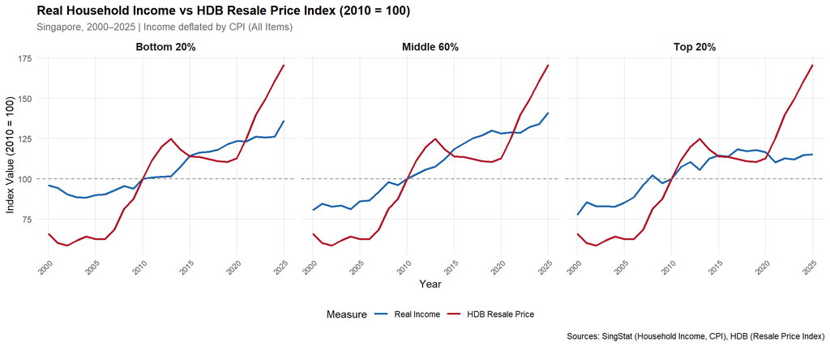

Figure 1: Real Household Income vs HDB Resale Price Index (2010 = 100)

```r
tidy_data <- tidy_data %>%
  mutate(
    Income_Group = factor(Income_Group, levels = c("Bottom 20%", "Middle 60%", "Top 20%")),
    Measure_Type = factor(Measure_Type, levels = c("Real Income", "HDB Resale Price"))
  )

ggplot(tidy_data, aes(x = Year, y = Index_Value, color = Measure_Type)) +
  geom_line(linewidth = 1) +
  geom_hline(yintercept = 100, linetype = "dashed", color = "grey50", linewidth = 0.4) +
  facet_wrap(~Income_Group, ncol = 3) +
  scale_color_manual(values = c("Real Income" = "#2166AC", "HDB Resale Price" = "#B2182B")) +
  scale_x_continuous(breaks = seq(2000, 2025, by = 5)) +
  labs(
    title = "Real Household Income vs HDB Resale Price Index (2010 = 100)",
    subtitle = "Singapore, 2000–2025 | Income deflated by CPI (All Items)",
    x = "Year", y = "Index Value (2010 = 100)",
    color = "Measure",
    caption = "Sources: SingStat (Household Income, CPI), HDB (Resale Price Index)"
  ) +
  theme_minimal(base_size = 11) +
  theme(
    legend.position = "bottom",
    strip.text = element_text(face = "bold", size = 11),
    plot.title = element_text(face = "bold", size = 13),
    plot.subtitle = element_text(size = 10, color = "grey40"),
    panel.grid.minor = element_blank(),
    axis.text.x = element_text(angle = 45, hjust = 1, size = 8)
  )
```

The faceted line chart reveals that prior to 2010, all three income groups had real income indices running broadly in line with or above the HDB resale price index, suggesting relative affordability stability in the early 2000s. Post-2010, the HDB Resale Price Index diverges sharply upward, by 2025, it reaches 171.0 compared to 136.3, 141.2, and 115.3 for Bottom 20%, Middle 60%, and Top 20% real income respectively. Notably, the Top 20% panel shows the widest gap in absolute terms by 2025, which appears counterintuitive but reflects that high-income nominal growth was partly offset by CPI deflation, while resale prices continued to rise. The Bottom 20% panel shows the most concerning trajectory, real income growth has lagged behind HDB price growth since approximately 2021, coinciding with the post-COVID resale market surge.

#### 5.6.2 Affordability Gap by Income Group

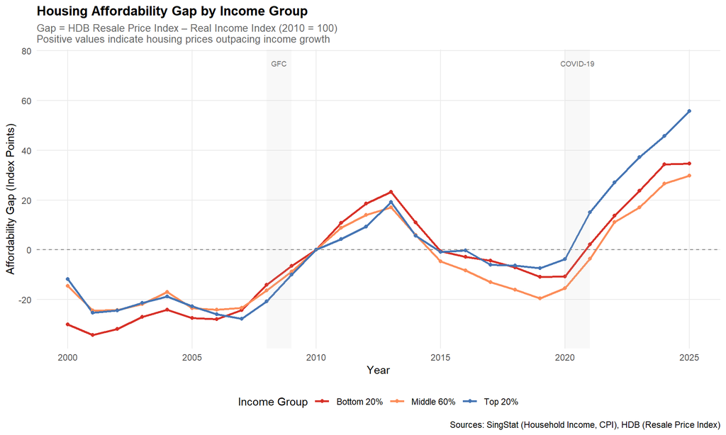

Figure 2: Housing Affordability Gap by Income Group

```r
gap_data <- tidy_data %>%
  pivot_wider(names_from = Measure_Type, values_from = Index_Value) %>%
  mutate(Affordability_Gap = `HDB Resale Price` - `Real Income`)

ggplot(gap_data, aes(x = Year, y = Affordability_Gap, color = Income_Group)) +
  geom_line(linewidth = 1) +
  geom_point(size = 1.5) +
  geom_hline(yintercept = 0, linetype = "dashed", color = "grey50") +
  scale_color_manual(values = c("Bottom 20%" = "#D73027", "Middle 60%" = "#FC8D59", "Top 20%" = "#4575B4")) +
  scale_x_continuous(breaks = seq(2000, 2025, by = 5)) +
  annotate("rect", xmin = 2008, xmax = 2009, ymin = -Inf, ymax = Inf, alpha = 0.1, fill = "grey") +
  annotate("text", x = 2008.5, y = 75, label = "GFC", size = 2.5, color = "grey40") +
  annotate("rect", xmin = 2020, xmax = 2021, ymin = -Inf, ymax = Inf, alpha = 0.1, fill = "grey") +
  annotate("text", x = 2020.5, y = 75, label = "COVID-19", size = 2.5, color = "grey40") +
  labs(
    title = "Housing Affordability Gap by Income Group",
    subtitle = "Gap = HDB Resale Price Index – Real Income Index (2010 = 100)\nPositive values indicate housing prices outpacing income growth",
    x = "Year", y = "Affordability Gap (Index Points)",
    color = "Income Group",
    caption = "Sources: SingStat (Household Income, CPI), HDB (Resale Price Index)"
  ) +
  theme_minimal(base_size = 11) +
  theme(
    legend.position = "bottom",
    plot.title = element_text(face = "bold", size = 13),
    plot.subtitle = element_text(size = 10, color = "grey40"),
    panel.grid.minor = element_blank()
  )
```

The resulting dataset contains four primary analytical dimensions:

1. Year (time dimension),
2. Income Group (distributional dimension),
3. Measure Type (Real Income vs Housing Price),
4. Indexed Value (quantitative measure).

This multidimensional structure enables comparative layering and faceted visualization while maintaining analytical clarity.

## 6 Planned Data Analysis

The following analytical methods will be applied to support and extend the visualization findings:

**1. Compound Annual Growth Rate (CAGR) Comparison** CAGR will be computed for real income and HDB resale prices across three sub-periods, 2000–2010 (pre-financial crisis to base year), 2010–2020 (post-GFC expansion), and 2020–2025 (COVID-19 and post-pandemic surge), for each income group. This allows structured identification of periods where housing price growth structurally outpaced income growth, and whether this divergence is accelerating.

**2. Affordability Gap Index** An affordability gap index (HDB Resale Price Index − Real Income Index) will be computed annually for each income group. A positive and widening gap indicates worsening affordability. This metric directly addresses the research question and will be annotated on the final visualization.

**3. Price-to-Income Ratio (Supplementary Metric)** A supplementary price-to-income ratio will be computed as nominal HDB Resale Price Index divided by nominal household income index (not deflated), to provide an alternative affordability lens that is more familiar to general audiences and policymakers. This will be included as a supporting annotation or table alongside the main visualization.

These methods are intentionally kept within descriptive and comparative analysis, consistent with the module’s scope, while providing sufficient analytical depth to generate meaningful and defensible insights.

## 8 Planned Work Distribution

| Team Member | Responsibilities |
| --- | --- |
| Shina Shih Xin Rong | Project coordination, narrative development, Quarto assembly |
| Jeanie Cherie Chua Yue-Ning | Data collection and raw data ingestion |
| Claudia Yue Xin Ying | Data transformation and index construction |
| Nurul Zahirah Binte Muhamadnoh | Visualization design and preliminary charts |
| Anushka Chourasia | Data validation, quality checks, and analysis support |

## 9 Appendix: Alternative Design Concepts

The following visual mockups are AI-generated conceptual charts created to illustrate potential visualization structures. These charts do not represent actual project data and are included solely to demonstrate design direction considered during the proposal stage.

### 9.1 Concept A: Small Multiples Line Chart (By Income Group)

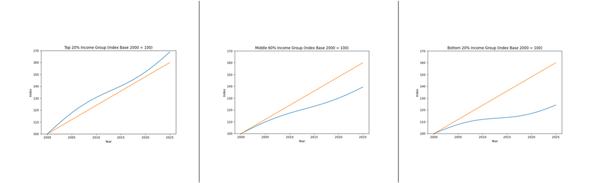

Concept A: Small Multiples Layout

This design separates income groups (Bottom 20%, Middle 60%, Top 20%) into individual panels with consistent y-axis scales.

Why considered: - Reduces visual clutter - Eliminates dual-axis distortion - Makes within-group divergence clear

Why not selected as primary design: - Requires more vertical space - Cross-group comparison less immediate

*Note: The preliminary visualization in Section 5.6 adopts a faceted layout structurally similar to Concept A. This was done intentionally for exploratory purposes, the faceted approach serves as the data engineering preview, while the final improved visualization will integrate the indexed comparison approach from Concept C with design refinements not possible at the proposal stage.*

### 9.2 Concept B: Income–Housing Gap Area Chart

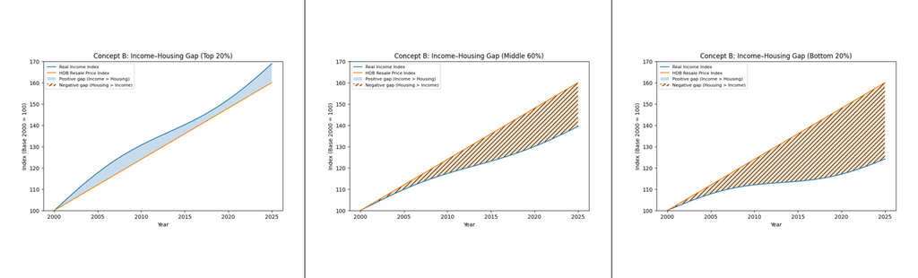

Concept B: Gap Area Visualization

This design shades the difference between real income index and housing price index to highlight affordability gaps.

Why considered: - Visually emphasises divergence - Intuitive for non-technical audiences

Why not selected: - Area shading may exaggerate perceived magnitude - Less academically neutral in tone

### 9.3 Concept C: Indexed Comparison (Base Year = 2010 = 100)

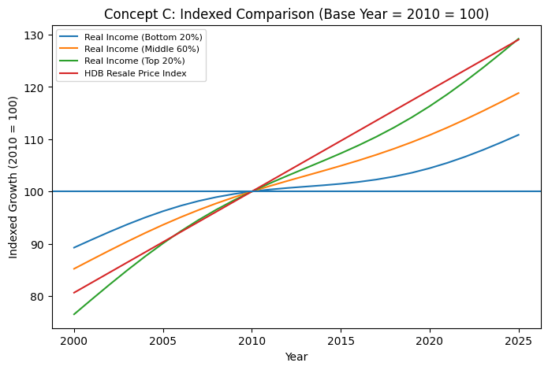

Concept C: Indexed Comparison

Indexed comparison removes nominal scale distortion and eliminates the dual-axis bias present in the original design. By converting income and housing series into normalised indices rebased to 2010 = 100, all variables share a common baseline, enabling direct growth comparison without perceptual manipulation.

Why preferred: - Standard economic practice - Removes scale distortion - Clean and professional - Supports analytical interpretation